# Logistic Regression - Predicting Diabetes Diagnosis

4/26/2020

## Data Cleaning/Preparation

The first thing that I did was read in the diabetes csv. After that I created the height.si variable by multiplying the height variable by 0.0254 and the weight.si variable by multiplying the weight variable by 0.453592. Next I created the bmi_categorised variable by calculating the bmi for each person and then using that to sort them into the categories of underweight, normal, overweight, and obese with the rest as NA. Lastly I recoded the insurance and smoking variables to reflect their value labels.

```r
# Import data
setwd("C:/Users/hayde/Documents/GitHub/INST408F")
diabetes <- read.csv("Homework 4/diabetes.csv")

# Create height.si
diabetes$height.si <- diabetes$height*0.0254

# Create weight.si
diabetes$weight.si <- diabetes$weight*0.453592

# Create bmi_categorised
diabetes$bmi <- diabetes$weight.si/diabetes$height.si^2
diabetes$bmi_categorised <- cut(diabetes$bmi,
                                breaks = c(0, 18.5, 25, 30, 100),
                                labels = c("underweight", "normal", "overweight", "obese"),
                                right = FALSE)

# Recode insurance variable
diabetes$insurance[diabetes$insurance == 0] <- "none"
diabetes$insurance[diabetes$insurance == 1] <- "government"
diabetes$insurance[diabetes$insurance == 2] <- "private"

# Recode smoking variable
diabetes$smoking[diabetes$smoking == 1] <- "current"
diabetes$smoking[diabetes$smoking == 2] <- "never"
diabetes$smoking[diabetes$smoking == 3] <- "ex-smoker"
```

## Exploratory Data Analysis

In the dataset there are 403 observations. Of those in the dataset 2.27% were underweight, 28.46% were of normal weight, 30.98% were overweight and 38.29% were obese by BMI. Additionally, 58.06% were Female and 41.94% were Male. 84.62% of those in the dataset did not have diabetes while 15.38% did. Lastly, the average age was 46.85 years old and the average BMI was 28.79.

```r
# Number of observations
nrow(diabetes)

# Precentages of BMI categories
prop.table(table(diabetes$bmi_categorised))*100

# Precentages of gender categories
prop.table(table(diabetes$gender))*100


# Precentages of diabetes categories
prop.table(table(diabetes$dm))*100

# Average age
mean(diabetes$age)

# Average BMI
mean(diabetes$bmi, na.rm = TRUE)
```

## Data Visualization

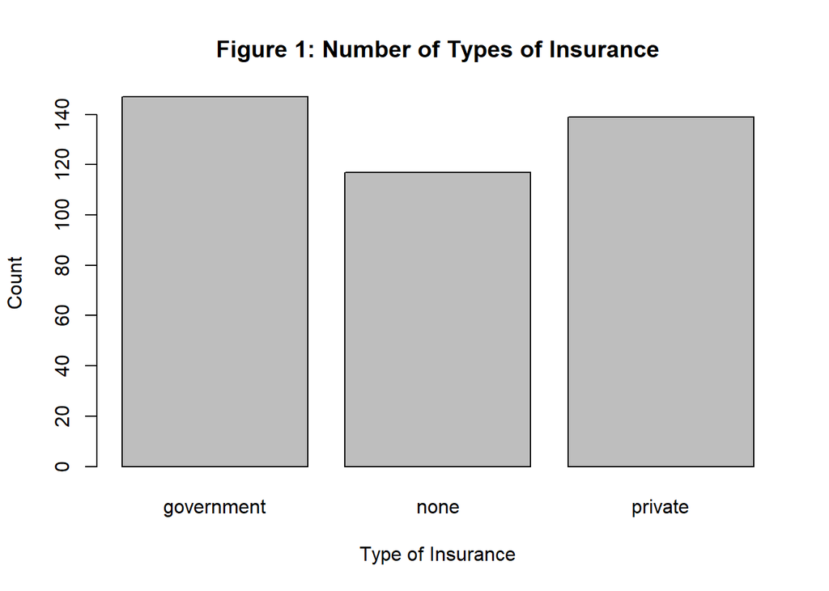

```r
# Plot insurance
barplot(table(diabetes$insurance),
        main = "Figure 1: Number of Types of Insurance", xlab = "Type of Insurance", ylab = "Count")
```

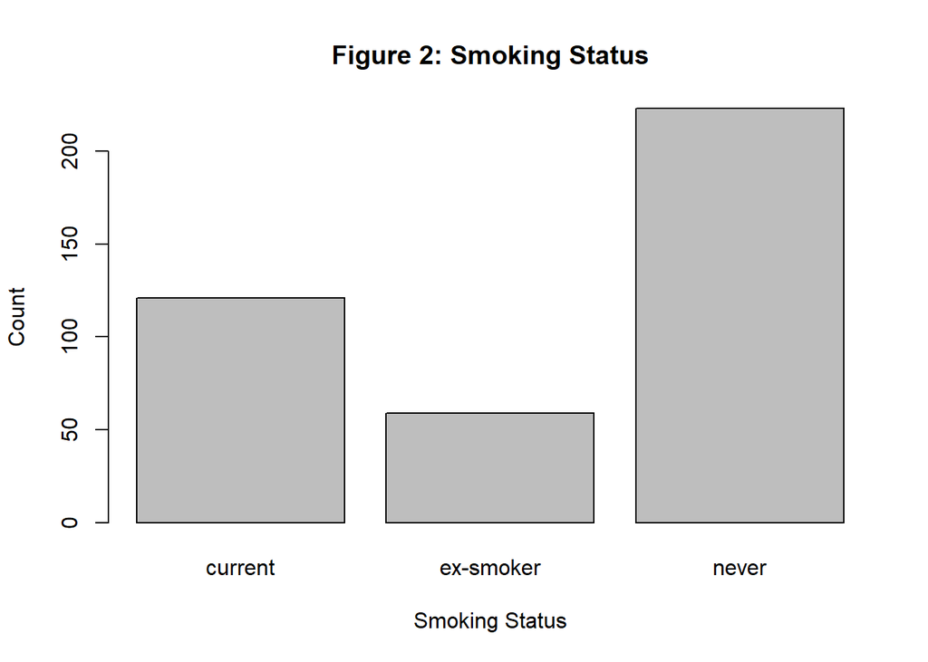

```r
# Plot smoking
barplot(table(diabetes$smoking),
        main = "Figure 2: Smoking Status", xlab = "Smoking Status", ylab = "Count")
```

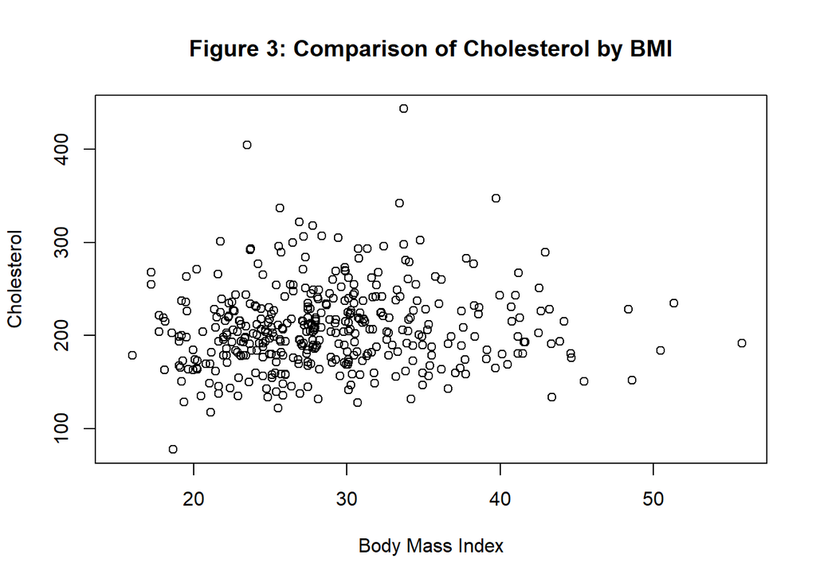

```r
# Plot BMI by Cholesterol
plot(diabetes$bmi, diabetes$chol,
     main = "Figure 3: Comparison of Cholesterol by BMI", xlab = "Body Mass Index", ylab = "Cholesterol")
```

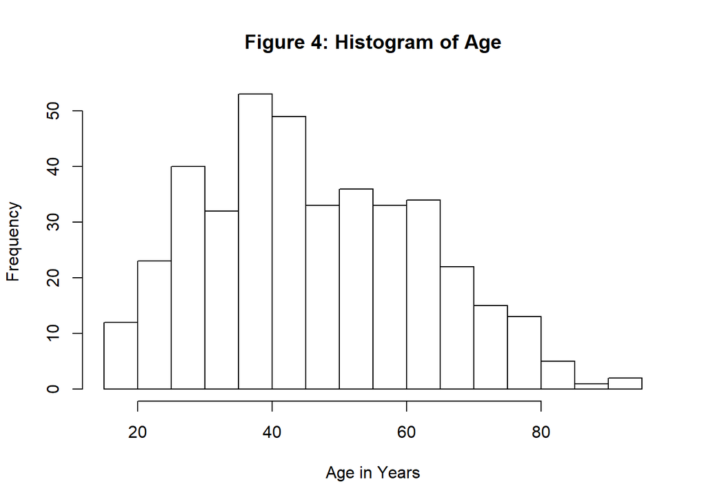

```r
# Histogram of age
hist(diabetes$age,
     breaks = 20,
     main = "Figure 4: Histogram of Age", xlab = "Age in Years", ylab = "Frequency")
```

## Logistic Regression Results

- Age: A one year increase in age causes the log odds of having diabetes to increase by 0.055454, holding the other independent variables constant
- Gender: The log odds of having diabetes between someone who is Male and someone who is female is 0.244852, holding the other independent variables constant
- BMI: A one unit increase in BMI causes the log odds of having diabetes to increase by 0.073879, holding the other independent variables constant

```r
# Multiple Linear Regression
MLR <- glm(data = diabetes, dm ~ age + gender + bmi, family = "binomial")
summary(MLR)
```